# 04 dataset visualizations

## Where nonprofits recieved funding from- new pie chart (not working)

[figure not shown]

```r
# Load necessary libraries
library(ggplot2)
library(dplyr)
library(tidyr)
library(ggrepel)

# Read and select relevant columns
dataRcv <- read_csv("YEAR-04-DATA-PUF.csv")
dataRcv <- dataRcv %>%
  select(ntee1,
         FndRaise_LocGvtGrnt_Rcv, FndRaise_StateGvtGrnt_Rcv, FndRaise_FedGvtGrnt_Rcv,
         FndRaise_LocGvtCntrct_Rcv, FndRaise_StateGvtCntrct_Rcv, FndRaise_FedGvtCntrct_Rcv,
         FndRaise_PFGrnt_Rcv, FndRaise_CFGrnt_Rcv, FndRaise_DAF_Rcv,
         FndRaise_Corp_Found_Grnt_Rcv, FndRaise_UntdWy_Rcv, FndRaise_CombFedCmpgn_Rcv,
         FndRaise_OthrGvngPrgrm_Rcv)

# Reshape data to long format
dataRcv_long <- dataRcv %>%
  pivot_longer(cols = starts_with("FndRaise_"), names_to = "Rcv_column", values_to = "Rcv_value")

# Filter for rows where the organization receives funding (Rcv_value == 1)
dataRcv_long1 <- dataRcv_long %>%
  filter(Rcv_value == 1)

# Re-coding the funding categories to more human-readable labels
dataRcv_long2 <- dataRcv_long1 %>%
  mutate(Rcv_value = case_when(
    Rcv_column == "FndRaise_LocGvtGrnt_Rcv" ~ "Local government grants",
    Rcv_column == "FndRaise_StateGvtGrnt_Rcv" ~ "State government grants",
    Rcv_column == "FndRaise_FedGvtGrnt_Rcv" ~ "Federal government grants",
    Rcv_column == "FndRaise_LocGvtCntrct_Rcv" ~ "Local government contracts",
    Rcv_column == "FndRaise_StateGvtCntrct_Rcv" ~ "State government contracts",
    Rcv_column == "FndRaise_FedGvtCntrct_Rcv" ~ "Federal government contracts",
    Rcv_column == "FndRaise_PFGrnt_Rcv" ~ "Private foundation grants",
    Rcv_column == "FndRaise_CFGrnt_Rcv" ~ "Community foundation grants",
    Rcv_column == "FndRaise_DAF_Rcv" ~ "Donor advised funds",
    Rcv_column == "FndRaise_Corp_Found_Grnt_Rcv" ~ "Corporate grants",
    Rcv_column == "FndRaise_UntdWy_Rcv" ~ "United Way grants",
    Rcv_column == "FndRaise_CombFedCmpgn_Rcv" ~ "Combined Federal Campaign",
    Rcv_column == "FndRaise_OthrGvngPrgrm_Rcv" ~ "Other federated giving programs",
    TRUE ~ NA_character_
  ))

# Counting the number of organizations receiving each type of funding and calculating percentage
Rcv_counts <- dataRcv_long2 %>%
  count(Rcv_value, name = "count") %>%
  mutate(percentage = count / sum(count) * 100)

# Visualize the funding counts
ggplot(Rcv_counts, aes(x = Rcv_value, y = percentage, fill = Rcv_value)) +
  geom_bar(stat = "identity", color = "white") +
  theme_minimal() +
  labs(title = "Where Nonprofits Received Funding From", fill = "Funding Source")
```

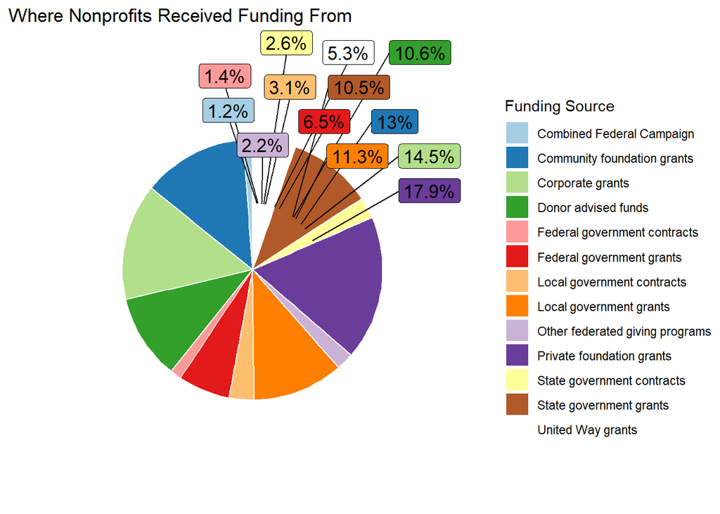

```r
# Filtering for categories with more than 1% of the total
Rcv_counts_filtered <- Rcv_counts %>%
  filter(percentage > 1)

# Create a pie chart visualization with labels
ggplot(Rcv_counts_filtered, aes(x = "", y = percentage, fill = Rcv_value)) +
  geom_bar(stat = "identity", width = 1, color = "white") +
  coord_polar(theta = "y") +
  theme_void() +
  labs(title = "Where Nonprofits Received Funding From", fill = "Funding Source") +
  geom_label_repel(aes(label = paste0(round(percentage, 1), "%")),
                   size = 4.5,
                   nudge_x = 1,
                   max.overlaps = 30,
                   show.legend = FALSE) +
  scale_fill_brewer(palette = "Paired")
```

## Where nonprofits recieved funding from- old pie chart (working)

```r
dataRcv <- read_csv("YEAR-04-DATA-PUF.csv")
```

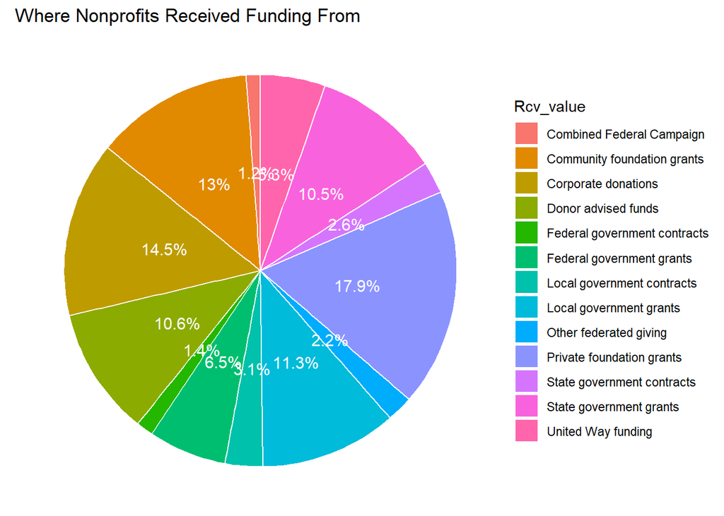

```r
dataRcv <- dataRcv |>
  select(ntee1,
         FndRaise_LocGvtGrnt_Rcv,
         FndRaise_StateGvtGrnt_Rcv,
         FndRaise_FedGvtGrnt_Rcv,
         FndRaise_LocGvtCntrct_Rcv,
         FndRaise_StateGvtCntrct_Rcv,
         FndRaise_FedGvtCntrct_Rcv,
         FndRaise_PFGrnt_Rcv,
         FndRaise_CFGrnt_Rcv,
         FndRaise_DAF_Rcv,
         FndRaise_Corp_Found_Grnt_Rcv,
         FndRaise_UntdWy_Rcv,
         FndRaise_CombFedCmpgn_Rcv,
         FndRaise_OthrGvngPrgrm_Rcv)


dataRcv_long <- dataRcv |>
  pivot_longer(
    cols = c(
      FndRaise_LocGvtGrnt_Rcv,
      FndRaise_StateGvtGrnt_Rcv,
      FndRaise_FedGvtGrnt_Rcv,
      FndRaise_LocGvtCntrct_Rcv,
      FndRaise_StateGvtCntrct_Rcv,
      FndRaise_FedGvtCntrct_Rcv,
      FndRaise_PFGrnt_Rcv,
      FndRaise_CFGrnt_Rcv,
      FndRaise_DAF_Rcv,
      FndRaise_Corp_Found_Grnt_Rcv,
      FndRaise_UntdWy_Rcv,
      FndRaise_CombFedCmpgn_Rcv,
      FndRaise_OthrGvngPrgrm_Rcv
    ),
    names_to = "Rcv_column",
    values_to = "Rcv_value"
  )

# Filter to only rows where the funding source was received (1)
dataRcv_long1 <- dataRcv_long |>
  filter(Rcv_value == "1")

# Convert variable names to labels
dataRcv_long2 <- dataRcv_long1 |>
  mutate(Rcv_value = case_when(
    Rcv_column == "FndRaise_LocGvtGrnt_Rcv" ~ "Local government grants",
    Rcv_column == "FndRaise_StateGvtGrnt_Rcv" ~ "State government grants",
    Rcv_column == "FndRaise_FedGvtGrnt_Rcv" ~ "Federal government grants",
    Rcv_column == "FndRaise_LocGvtCntrct_Rcv" ~ "Local government contracts",
    Rcv_column == "FndRaise_StateGvtCntrct_Rcv" ~ "State government contracts",
    Rcv_column == "FndRaise_FedGvtCntrct_Rcv" ~ "Federal government contracts",
    Rcv_column == "FndRaise_PFGrnt_Rcv" ~ "Private foundation grants",
    Rcv_column == "FndRaise_CFGrnt_Rcv" ~ "Community foundation grants",
    Rcv_column == "FndRaise_DAF_Rcv" ~ "Donor advised funds",
    Rcv_column == "FndRaise_Corp_Found_Grnt_Rcv" ~ "Corporate donations",
    Rcv_column == "FndRaise_UntdWy_Rcv" ~ "United Way funding",
    Rcv_column == "FndRaise_CombFedCmpgn_Rcv" ~ "Combined Federal Campaign",
    Rcv_column == "FndRaise_OthrGvngPrgrm_Rcv" ~ "Other federated giving",
    TRUE ~ NA_character_
  ))

# Count and calculate percentages of each funding type
Rcv_counts <- dataRcv_long2 |>
  count(Rcv_value, name = "count") |>
  mutate(percentage = count / sum(count) * 100)

# Create a pie chart of overall funding sources
ggplot(Rcv_counts, aes(x = "", y = percentage, fill = Rcv_value)) +
  geom_bar(stat = "identity", width = 1, color = "white") +
  coord_polar(theta = "y") +
  theme_void() +
  labs(title = "Where Nonprofits Received Funding From") +
  geom_text(aes(label = paste0(round(percentage, 1), "%")),
            position = position_stack(vjust = 0.5),
            color = "white", size = 4)
```

## Recieved Funding Types by Broad Nonprofit Sector Group

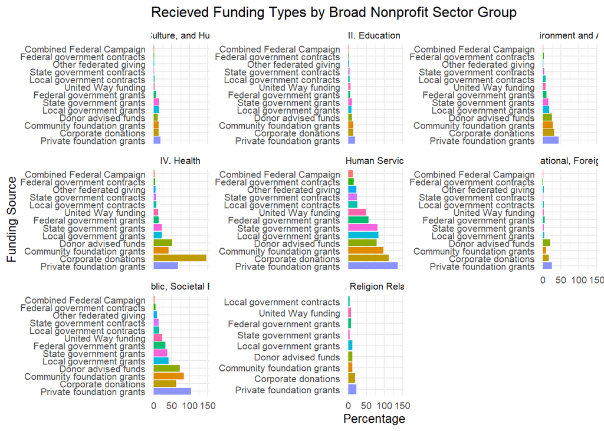

```r
Rcv_by_sector <- dataRcv_long2 |>
  count(ntee1, Rcv_value, name = "count") |>
  group_by(ntee1) |>
  mutate(percentage = count / sum(count) * 100) |>
  ungroup()


# Group ntee1 codes into broader sector categories
Rcv_by_sector <- Rcv_by_sector |>
  mutate(sector_group = case_when(
    ntee1 == "A" ~ "I. Arts, Culture, and Humanities",
    ntee1 == "B" ~ "II. Education",
    ntee1 %in% c("C", "D") ~ "III. Environment and Animals",
    ntee1 %in% c("E", "F", "G", "H") ~ "IV. Health",
    ntee1 %in% c("I", "J", "K", "L", "M", "N", "O", "P") ~ "V. Human Services",
    ntee1 == "Q" ~ "VI. International, Foreign Affairs",
    ntee1 %in% c("R", "S", "T", "U", "V", "W") ~ "VII. Public, Societal Benefit",
    ntee1 == "X" ~ "VIII. Religion Related",
    ntee1 == "Y" ~ "IX. Mutual/Membership Benefit",
    ntee1 == "Z" ~ "X. Unknown, Unclassified",
    TRUE ~ "Other"
  ))




ggplot(Rcv_by_sector, aes(x = reorder(Rcv_value, -percentage), y = percentage, fill = Rcv_value)) +
  geom_col(show.legend = FALSE) +
  facet_wrap(~ sector_group, scales = "free_y") +
  coord_flip() +
  labs(
    title = "Recieved Funding Types by Broad Nonprofit Sector Group",
    x = "Funding Source",
    y = "Percentage"
  ) +
  theme_minimal(base_size = 10)
```

## Recieved Funding Types (GROUPED)

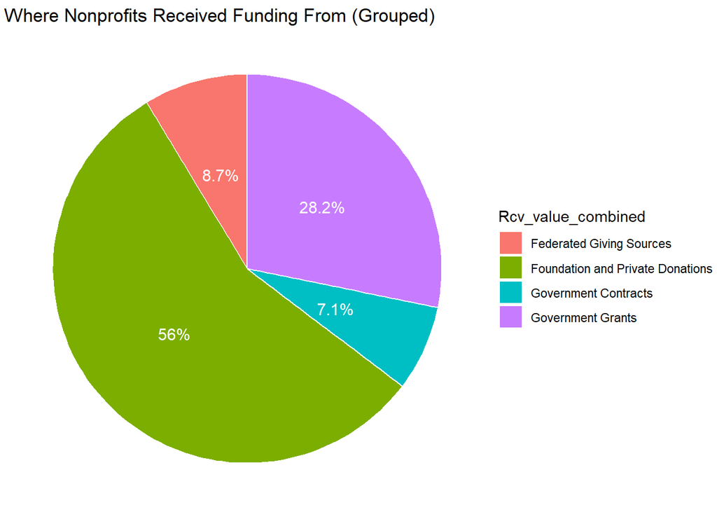

```r
# Assuming you've already loaded and processed dataRcv_long2
dataRcv_long2 <- dataRcv_long1 |>
  mutate(Rcv_value_combined = case_when(
    # Federated Giving Sources
    Rcv_column %in% c("FndRaise_CombFedCmpgn_Rcv", "FndRaise_OthrGvngPrgrm_Rcv", "FndRaise_UntdWy_Rcv") ~ "Federated Giving Sources",

    # Government Grants
    Rcv_column %in% c("FndRaise_FedGvtGrnt_Rcv", "FndRaise_StateGvtGrnt_Rcv", "FndRaise_LocGvtGrnt_Rcv") ~ "Government Grants",

    # Government Contracts
    Rcv_column %in% c("FndRaise_FedGvtCntrct_Rcv", "FndRaise_StateGvtCntrct_Rcv", "FndRaise_LocGvtCntrct_Rcv") ~ "Government Contracts",

    # Foundation and Private Donations
    Rcv_column %in% c("FndRaise_PFGrnt_Rcv", "FndRaise_CFGrnt_Rcv", "FndRaise_Corp_Found_Grnt_Rcv", "FndRaise_DAF_Rcv") ~ "Foundation and Private Donations",

    # Any other sources
    TRUE ~ "Other Sources"
  ))

# Now you can count and calculate the percentage of each category
Rcv_counts_combined <- dataRcv_long2 |>
  count(Rcv_value_combined, name = "count") |>
  mutate(percentage = count / sum(count) * 100)

# Create a pie chart of the combined funding sources
ggplot(Rcv_counts_combined, aes(x = "", y = percentage, fill = Rcv_value_combined)) +
  geom_bar(stat = "identity", width = 1, color = "white") +
  coord_polar(theta = "y") +
  theme_void() +
  labs(title = "Where Nonprofits Received Funding From (Grouped)") +
  geom_text(aes(label = paste0(round(percentage, 1), "%")),
            position = position_stack(vjust = 0.5),
            color = "white", size = 4)
```

## Recieved Funding Types (GROUPED) by Broad Nonprofit Sector Group

```r
# Load the necessary dataset
dataRcv <- read_csv("YEAR-04-DATA-PUF.csv")
```

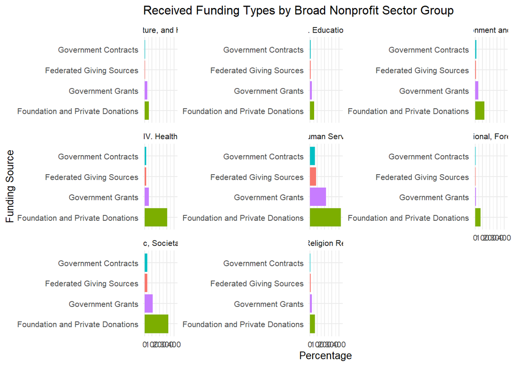

```r
# Select relevant columns for the analysis
dataRcv <- dataRcv |>
  select(
    ntee1,
    FndRaise_LocGvtGrnt_Rcv,
    FndRaise_StateGvtGrnt_Rcv,
    FndRaise_FedGvtGrnt_Rcv,
    FndRaise_LocGvtCntrct_Rcv,
    FndRaise_StateGvtCntrct_Rcv,
    FndRaise_FedGvtCntrct_Rcv,
    FndRaise_PFGrnt_Rcv,
    FndRaise_CFGrnt_Rcv,
    FndRaise_DAF_Rcv,
    FndRaise_Corp_Found_Grnt_Rcv,
    FndRaise_UntdWy_Rcv,
    FndRaise_CombFedCmpgn_Rcv,
    FndRaise_OthrGvngPrgrm_Rcv
  )

# Pivoting the data to long format
dataRcv_long <- dataRcv |>
  pivot_longer(
    cols = starts_with("FndRaise"),  # Pivot only the funding-related columns
    names_to = "Rcv_column",
    values_to = "Rcv_value"
  )

# Filter to keep only rows where the funding source was received (Rcv_value == 1)
dataRcv_long1 <- dataRcv_long |>
  filter(Rcv_value == 1)

# Convert funding column names into human-readable labels and group into broader categories
dataRcv_long2 <- dataRcv_long1 |>
  mutate(Rcv_value_combined = case_when(
    # Federated Giving Sources
    Rcv_column %in% c("FndRaise_CombFedCmpgn_Rcv", "FndRaise_OthrGvngPrgrm_Rcv", "FndRaise_UntdWy_Rcv") ~ "Federated Giving Sources",

    # Government Grants
    Rcv_column %in% c("FndRaise_FedGvtGrnt_Rcv", "FndRaise_StateGvtGrnt_Rcv", "FndRaise_LocGvtGrnt_Rcv") ~ "Government Grants",

    # Government Contracts
    Rcv_column %in% c("FndRaise_FedGvtCntrct_Rcv", "FndRaise_StateGvtCntrct_Rcv", "FndRaise_LocGvtCntrct_Rcv") ~ "Government Contracts",

    # Foundation and Private Donations
    Rcv_column %in% c("FndRaise_PFGrnt_Rcv", "FndRaise_CFGrnt_Rcv", "FndRaise_Corp_Found_Grnt_Rcv", "FndRaise_DAF_Rcv") ~ "Foundation and Private Donations",

    # Other Sources of Funding
    TRUE ~ "Other Sources"
  ))

# Group by sector and funding type, then calculate percentage
Rcv_by_sector_combined <- dataRcv_long2 |>
  group_by(ntee1, Rcv_value_combined) |>
  summarise(count = n(), .groups = "drop") |>
  group_by(ntee1) |>
  mutate(percentage = (count / sum(count)) * 100) |>
  ungroup()

# Group ntee1 codes into broader sector categories
Rcv_by_sector_combined <- Rcv_by_sector_combined |>
  mutate(sector_group = case_when(
    ntee1 == "A" ~ "I. Arts, Culture, and Humanities",
    ntee1 == "B" ~ "II. Education",
    ntee1 %in% c("C", "D") ~ "III. Environment and Animals",
    ntee1 %in% c("E", "F", "G", "H") ~ "IV. Health",
    ntee1 %in% c("I", "J", "K", "L", "M", "N", "O", "P") ~ "V. Human Services",
    ntee1 == "Q" ~ "VI. International, Foreign Affairs",
    ntee1 %in% c("R", "S", "T", "U", "V", "W") ~ "VII. Public, Societal Benefit",
    ntee1 == "X" ~ "VIII. Religion Related",
    ntee1 == "Y" ~ "IX. Mutual/Membership Benefit",
    ntee1 == "Z" ~ "X. Unknown, Unclassified",
    TRUE ~ "Other"
  ))

# Sort ntee1 values based on the new sector_group
Rcv_by_sector_combined <- Rcv_by_sector_combined |>
  mutate(sector_group = factor(sector_group, levels = c(
    "I. Arts, Culture, and Humanities",
    "II. Education",
    "III. Environment and Animals",
    "IV. Health",
    "V. Human Services",
    "VI. International, Foreign Affairs",
    "VII. Public, Societal Benefit",
    "VIII. Religion Related",
    "IX. Mutual/Membership Benefit",
    "X. Unknown, Unclassified",
    "Other"
  )))

# Create a bar plot (faceted) for funding sources by sector group
ggplot(Rcv_by_sector_combined, aes(x = reorder(Rcv_value_combined, -percentage), y = percentage, fill = Rcv_value_combined)) +
  geom_col(show.legend = FALSE) +
  facet_wrap(~ sector_group, scales = "free_y") +  # Facet by sector group
  coord_flip() +  # Flip the bars to horizontal
  labs(
    title = "Received Funding Types by Broad Nonprofit Sector Group",
    x = "Funding Source",
    y = "Percentage"
  ) +
  theme_minimal(base_size = 10)
```

## Anova- whether the CEO race impacts funding:

p-value = 0.172: Since this is greater than 0.05, it means there is no significant difference in the funding (TotRev_clean) based on the CEO race (ceo_race_label).

So, no- the race of the CEO does not have an impact statistically on funding.

```r
data04 <- read_csv("YEAR-04-DATA-PUF.csv")
race_labels <- c(
  "1" = "Asian or Pacific Islander",
  "2" = "Black or African American",
  "3" = "Hispanic or Latino",
  "4" = "Native American",
  "5" = "White",
  "6" = "Multiracial",
  "7" = "Other"
)

data04 <- data04 |>
  filter(!is.na(CEOrace)) |>
  mutate(ceo_race_label = recode(as.character(CEOrace), !!!race_labels))



#ANOVA- the impact of 'CEOrace' on 'TotRev_clean'
anova_result <- aov(TotRev_clean ~ ceo_race_label, data = data04)


summary(anova_result)
```

```
##                  Df    Sum Sq   Mean Sq F value Pr(>F)
## ceo_race_label    6 3.251e+13 5.418e+12   1.507  0.172
## Residuals      3115 1.120e+16 3.595e+12
## 216 observations deleted due to missingness
```

## Anova- Significant differences in funding based on geographic focus.

The geographic focus (geo_focus) has a strong impact on the amount of funding a nonprofit receives, and this relationship is highly statistically significant.

Based on the ANOVA results, you can conclude that the amount of funding a nonprofit receives does depend on the geographic area where it provides services. Specifically:

The p-value (3.95e-10) is extremely small, indicating that the differences in funding (TotRev_clean) between the different geo_focus categories (such as local, national, international, etc.) are highly statistically significant.

The F-value (9.3) suggests that the differences in funding between the groups (geographic areas) are large relative to the variation within each group. This means that the geographic area a nonprofit serves plays an important role in determining how much funding it receives.

```r
# getting geo Areas into one column
data_cleaned <- data04 |>
  mutate(geo_focus = case_when(
    GeoAreas_Local == 1 ~ "Local",
    GeoAreas_MultipleLocal == 1 ~ "Multiple Local",
    GeoAreas_RegionalWithin == 1 ~ "Regional Within State",
    GeoAreas_RegionalAcross == 1 ~ "Regional Across States",
    GeoAreas_National == 1 ~ "National",
    GeoAreas_International == 1 ~ "International",
    TRUE ~ "Other"
  ))




# ANOVA
anova_result_geo_focus <- aov(TotRev_clean ~ geo_focus, data = data_cleaned)

# Display the ANOVA result
summary(anova_result_geo_focus)
```

```
##               Df    Sum Sq   Mean Sq F value   Pr(>F)
## geo_focus      6 1.976e+14 3.294e+13     9.3 3.95e-10 ***
## Residuals   3115 1.103e+16 3.542e+12
## ---
## Signif. codes:  0 '***' 0.001 '**' 0.01 '*' 0.05 '.' 0.1 ' ' 1
## 216 observations deleted due to missingness
```

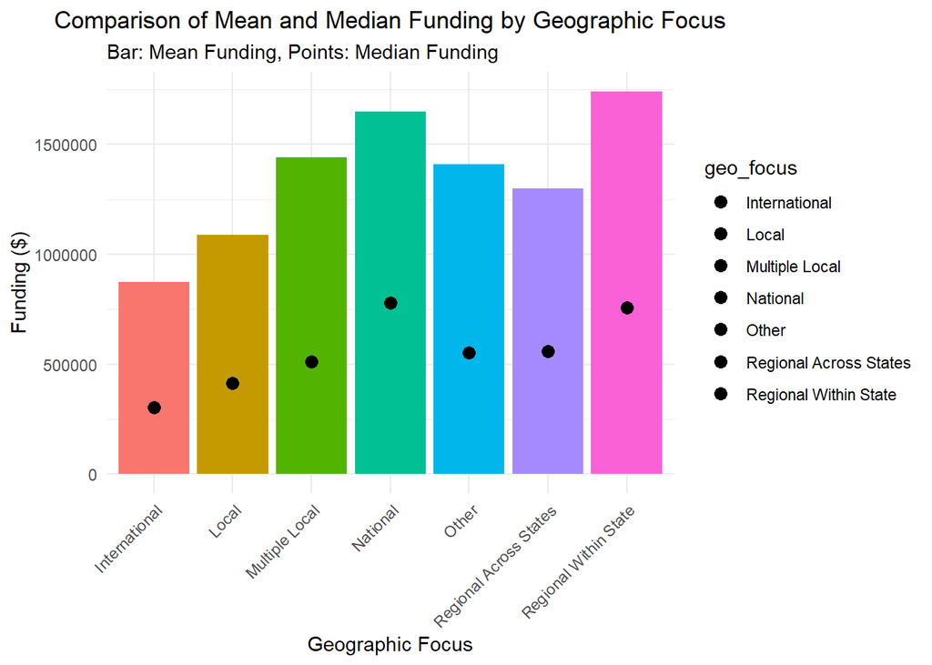

```r
# Prepare the data for visualization
funding_by_geo_focus_sorted <- data.frame(
  geo_focus = c("Regional Within State", "National", "Multiple Local", "Other",
                "Regional Across States", "Local", "International"),
  mean_funding = c(1740585.5, 1650063.6, 1439560.8, 1407966.7, 1298158.2,
                   1088753.1, 873768.2),
  median_funding = c(755857.9, 778931.2, 512280.3, 550776.6, 559973.1,
                     414651.9, 302402.4)
)

# Create the bar plot for mean funding and overlay with median funding as points
ggplot(funding_by_geo_focus_sorted, aes(x = geo_focus, y = mean_funding, fill = geo_focus)) +
  geom_bar(stat = "identity", show.legend = FALSE) +  # Bar chart for mean funding
  geom_point(aes(y = median_funding), color = "black", size = 3) +  # Points for median funding
  labs(title = "Comparison of Mean and Median Funding by Geographic Focus",
       x = "Geographic Focus",
       y = "Funding ($)",
       subtitle = "Bar: Mean Funding, Points: Median Funding") +
  theme_minimal() +
  theme(axis.text.x = element_text(angle = 45, hjust = 1),  # Rotate x-axis labels for readability
        plot.title = element_text(hjust = 0.5))  # Center the title
```

## which geographic area (local, national, international, etc.) gets the most funding based on the mean of “TotRev_clean”

Regional and National Focus: Nonprofits that focus on regional (within state) and national areas tend to receive the highest average funding, likely due to their broader outreach, access to larger donor bases, or ability to attract government funding.

Local and International Focus: Local nonprofits tend to receive lower average funding compared to regional or national ones. Similarly, international nonprofits receive the lowest average funding, which may indicate more challenges in raising large sums or fewer funding sources.

```r
funding_by_geo_focus <- data_cleaned |>
  group_by(geo_focus) |>
  summarise(mean_funding = mean(TotRev_clean, na.rm = TRUE),
            median_funding = median(TotRev_clean, na.rm = TRUE))


funding_by_geo_focus_sorted <- funding_by_geo_focus |>
  arrange(desc(mean_funding))  # Sort in descending order

# View the sorted result
funding_by_geo_focus_sorted
```

```
## # A tibble: 7 × 3
##   geo_focus              mean_funding median_funding
##   <chr>                         <dbl>          <dbl>
## 1 Regional Within State      1740586.        755858.
## 2 National                   1650064.        778931.
## 3 Multiple Local             1439561.        512280.
## 4 Other                      1407967.        550777.
## 5 Regional Across States     1298158.        559973.
## 6 Local                      1088753.        414652.
## 7 International               873768.        302402.
```

## relationship between program focus variables and total revenue.

ProgDem_Children shows no significant difference in funding.

```r
# Load necessary libraries
library(dplyr)

# Define a list of all ProgDem_* variables
prog_dem_vars <- c("ProgDem_Children", "ProgDem_YoungAdults", "ProgDem_Adults",
                   "ProgDem_Elders", "ProgDem_Veterans", "ProgDem_Families",
                   "ProgDem_BelowFPL")

# Iterate over each ProgDem_* variable and run ANOVA
for (var in prog_dem_vars) {
  anova_result <- aov(TotRev_clean ~ get(var), data = data04)
  cat("\nANOVA results for", var, ":\n")
  print(summary(anova_result))
}
```

```
##
## ANOVA results for ProgDem_Children :
##               Df    Sum Sq   Mean Sq F value Pr(>F)
## get(var)       1 1.371e+12 1.371e+12   0.379  0.538
## Residuals   2631 9.532e+15 3.623e+12
## 705 observations deleted due to missingness
##
## ANOVA results for ProgDem_YoungAdults :
##               Df    Sum Sq   Mean Sq F value Pr(>F)
## get(var)       1 1.642e+13 1.642e+13   4.385 0.0364 *
## Residuals   2625 9.829e+15 3.744e+12
## ---
## Signif. codes:  0 '***' 0.001 '**' 0.01 '*' 0.05 '.' 0.1 ' ' 1
## 711 observations deleted due to missingness
##
## ANOVA results for ProgDem_Adults :
##               Df    Sum Sq   Mean Sq F value Pr(>F)
## get(var)       1 1.511e+13 1.511e+13    4.07 0.0438 *
## Residuals   2634 9.777e+15 3.712e+12
## ---
## Signif. codes:  0 '***' 0.001 '**' 0.01 '*' 0.05 '.' 0.1 ' ' 1
## 702 observations deleted due to missingness
##
## ANOVA results for ProgDem_Elders :
##               Df    Sum Sq   Mean Sq F value Pr(>F)
## get(var)       1 1.515e+13 1.515e+13   4.046 0.0444 *
## Residuals   2517 9.423e+15 3.744e+12
## ---
## Signif. codes:  0 '***' 0.001 '**' 0.01 '*' 0.05 '.' 0.1 ' ' 1
## 819 observations deleted due to missingness
##
## ANOVA results for ProgDem_Veterans :
##               Df    Sum Sq   Mean Sq F value Pr(>F)
## get(var)       1 1.907e+13 1.907e+13   5.213 0.0225 *
## Residuals   2206 8.069e+15 3.658e+12
## ---
## Signif. codes:  0 '***' 0.001 '**' 0.01 '*' 0.05 '.' 0.1 ' ' 1
## 1130 observations deleted due to missingness
##
## ANOVA results for ProgDem_Families :
##               Df    Sum Sq   Mean Sq F value Pr(>F)
## get(var)       1 3.420e+12 3.420e+12   0.948   0.33
## Residuals   2415 8.713e+15 3.608e+12
## 921 observations deleted due to missingness
##
## ANOVA results for ProgDem_BelowFPL :
##               Df    Sum Sq   Mean Sq F value Pr(>F)
## get(var)       1 2.247e+13 2.247e+13   6.075 0.0138 *
## Residuals   2553 9.444e+15 3.699e+12
## ---
## Signif. codes:  0 '***' 0.001 '**' 0.01 '*' 0.05 '.' 0.1 ' ' 1
## 783 observations deleted due to missingness
```

# Average revenue for each “focused program”. Tukey’s test to understand difference between primary and secondary focus.

Secondary Focus vs No Focus: The difference in funding is not statistically significant, meaning that nonprofits with a secondary focus on the program do not differ significantly in funding from those with no focus.

Secondary Focus vs Primary Focus: There is no significant difference in funding between nonprofits with a secondary focus and those with a primary focus.

```r
selected_columns <- c("TotRev_clean", "ProgDem_Children", "ProgDem_Veterans", "ProgDem_Families", "ProgDem_Adults")


data04_cleaned <- data04 |>
  mutate(
    ProgDem_Children = recode(ProgDem_Children, `0` = "No Focus", `1` = "Primary Focus", `2` = "Secondary Focus", `98` = NA_character_),
    ProgDem_Veterans = recode(ProgDem_Veterans, `0` = "No Focus", `1` = "Primary Focus", `2` = "Secondary Focus", `98` = NA_character_),
    ProgDem_Families = recode(ProgDem_Families, `0` = "No Focus", `1` = "Primary Focus", `2` = "Secondary Focus", `98` = NA_character_),
    ProgDem_Adults = recode(ProgDem_Adults, `0` = "No Focus", `1` = "Primary Focus", `2` = "Secondary Focus", `98` = NA_character_)
  )


data_long <- data04_cleaned |>
  select(all_of(selected_columns)) |>
  gather(key = "ProgramFocus", value = "Focus", -TotRev_clean) |>
  filter(!is.na(Focus)) |>
  filter(!is.na(TotRev_clean))# Remove rows with NA in Focus


str(data04$TotRev_clean)
```

```
##  num [1:3338] 39990 3774338 159115 2504899 NA ...
```

```r
class(data04$TotRev_clean)
```

```
## [1] "numeric"
```

```r
veterans_avg_revenue <- data04_cleaned |>
  filter(ProgDem_Veterans == "Primary Focus") |>
  summarise(AverageRevenue = mean(TotRev_clean, na.rm = TRUE))


children_avg_revenue <- data04_cleaned |>
  filter(ProgDem_Children == "Primary Focus") |>
  summarise(AverageRevenue = mean(TotRev_clean, na.rm = TRUE))


families_avg_revenue <- data04_cleaned |>
  filter(ProgDem_Families == "Primary Focus") |>
  summarise(AverageRevenue = mean(TotRev_clean, na.rm = TRUE))


adults_avg_revenue <- data04_cleaned |>
  filter(ProgDem_Adults == "Primary Focus") |>
  summarise(AverageRevenue = mean(TotRev_clean, na.rm = TRUE))


print(veterans_avg_revenue)
```

```
## # A tibble: 1 × 1
##   AverageRevenue
##            <dbl>
## 1       1373572.
```

```r
print(children_avg_revenue)
```

```
## # A tibble: 1 × 1
##   AverageRevenue
##            <dbl>
## 1       1335642.
```

```r
print(families_avg_revenue)
```

```
## # A tibble: 1 × 1
##   AverageRevenue
##            <dbl>
## 1       1191897.
```

```r
print(adults_avg_revenue)
```

```
## # A tibble: 1 × 1
##   AverageRevenue
##            <dbl>
## 1       1366930.
```

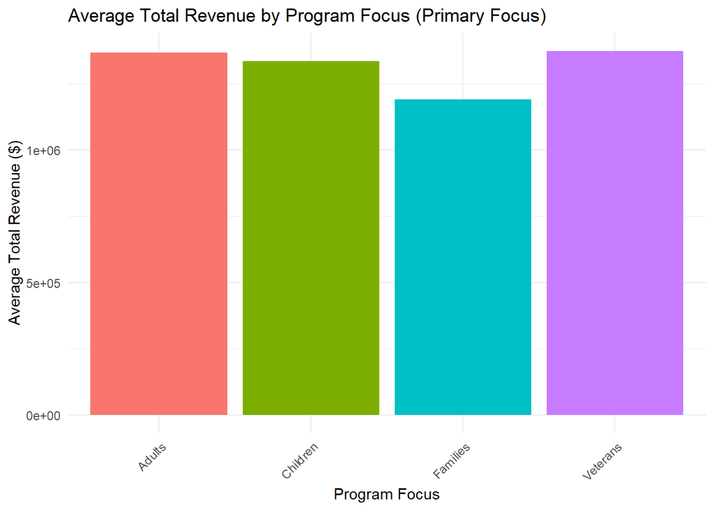

```r
avg_revenue_df <- data.frame(
  ProgramFocus = c("Veterans", "Children", "Families", "Adults"),
  AverageRevenue = c(
    veterans_avg_revenue$AverageRevenue,
    children_avg_revenue$AverageRevenue,
    families_avg_revenue$AverageRevenue,
    adults_avg_revenue$AverageRevenue
  )
)


ggplot(avg_revenue_df, aes(x = ProgramFocus, y = AverageRevenue, fill = ProgramFocus)) +
  geom_bar(stat = "identity", show.legend = FALSE) +
  labs(title = "Average Total Revenue by Program Focus (Primary Focus)",
       x = "Program Focus", y = "Average Total Revenue ($)") +
  theme_minimal() +
  theme(axis.text.x = element_text(angle = 45, hjust = 1))
```

```r
prog_dem_vars <- c("ProgDem_Children", "ProgDem_Veterans", "ProgDem_Families", "ProgDem_Adults")


for (var in prog_dem_vars) {
  anova_result <- aov(TotRev_clean ~ get(var), data = data04_cleaned)
  cat("\nANOVA results for", var, ":\n")
  print(summary(anova_result))
}
```

```
##
## ANOVA results for ProgDem_Children :
##               Df    Sum Sq   Mean Sq F value Pr(>F)
## get(var)       2 9.381e+12 4.690e+12   1.295  0.274
## Residuals   2630 9.524e+15 3.621e+12
## 705 observations deleted due to missingness
##
## ANOVA results for ProgDem_Veterans :
##               Df    Sum Sq   Mean Sq F value Pr(>F)
## get(var)       2 1.953e+13 9.764e+12   2.668 0.0696 .
## Residuals   2205 8.069e+15 3.659e+12
## ---
## Signif. codes:  0 '***' 0.001 '**' 0.01 '*' 0.05 '.' 0.1 ' ' 1
## 1130 observations deleted due to missingness
##
## ANOVA results for ProgDem_Families :
##               Df    Sum Sq   Mean Sq F value Pr(>F)
## get(var)       2 2.519e+13 1.259e+13   3.498 0.0304 *
## Residuals   2414 8.691e+15 3.600e+12
## ---
## Signif. codes:  0 '***' 0.001 '**' 0.01 '*' 0.05 '.' 0.1 ' ' 1
## 921 observations deleted due to missingness
##
## ANOVA results for ProgDem_Adults :
##               Df    Sum Sq   Mean Sq F value Pr(>F)
## get(var)       2 2.817e+13 1.408e+13   3.798 0.0225 *
## Residuals   2633 9.764e+15 3.708e+12
## ---
## Signif. codes:  0 '***' 0.001 '**' 0.01 '*' 0.05 '.' 0.1 ' ' 1
## 702 observations deleted due to missingness
```

```r
tukey_result <- TukeyHSD(anova_result)
print(tukey_result)
```

```
##   Tukey multiple comparisons of means
##     95% family-wise confidence level
##
## Fit: aov(formula = TotRev_clean ~ get(var), data = data04_cleaned)
##
## $`get(var)`
##                                    diff        lwr      upr     p adj
## Primary Focus-No Focus        268744.25   35945.83 501542.7 0.0187259
## Secondary Focus-No Focus      250599.40  -25469.16 526668.0 0.0842981
## Secondary Focus-Primary Focus -18144.85 -237644.47 201354.8 0.9794970
```

## Average funding based on sector

This chart indicates that nonprofits focusing on health, public benefit, and human services tend to have higher funding, while sectors such as religion-related nonprofits may receive less funding on average.

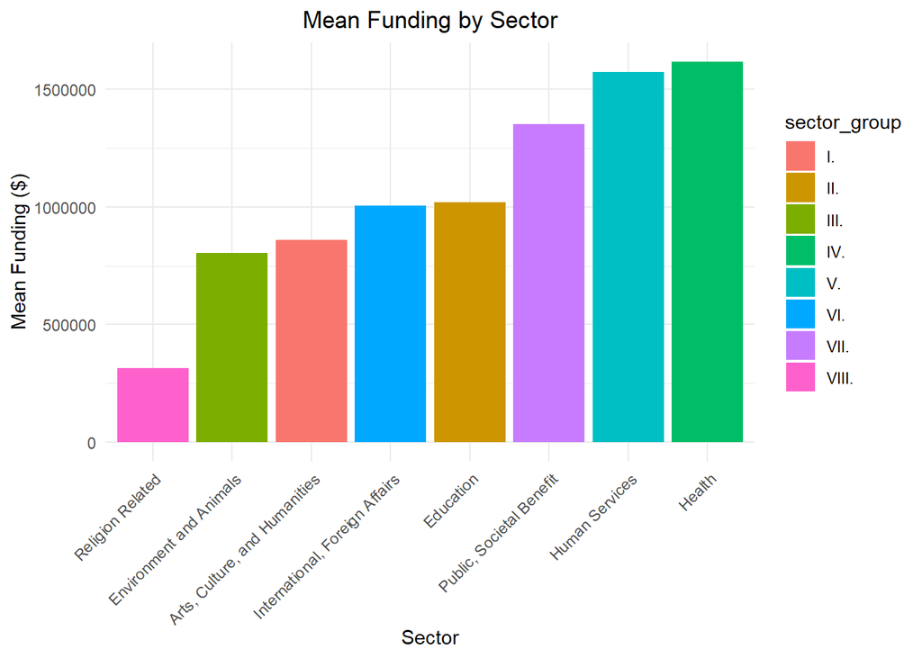

```r
data04_cleaned <- data04 |>
  mutate(across(contains("FndRaise_"), ~na_if(., 97), .names = "cleaned_{col}")) |>
  mutate(across(contains("FndRaise_"), ~na_if(., 98), .names = "cleaned_{col}")) |>
  mutate(across(contains("FndRaise_"), as.factor, .names = "factor_{col}"))


data04_cleaned$sector_group <- recode(data04_cleaned$ntee1,
                                      A = "I.", B = "II.", C = "III.", D = "III.",
                                      E = "IV.", F = "IV.", G = "IV.", H = "IV.",
                                      I = "V.", J = "V.", K = "V.", L = "V.",
                                      M = "V.", N = "V.", O = "V.", P = "V.",
                                      Q = "VI.", R = "VII.", S = "VII.", T = "VII.",
                                      U = "VII.", V = "VII.", W = "VII.",
                                      X = "VIII.", Y = "IX.", Z = "X.")


data04_cleaned$sector_group <- ifelse(is.na(data04_cleaned$sector_group), "Unknown", data04_cleaned$sector_group)


data04_cleaned$factor_FndRaise_TotExp <- factor(data04_cleaned$FndRaise_TotExp,
                                                 levels = c(1, 2, 3, 4, 5),
                                                 labels = c("Significantly Decrease", "Moderately Decrease", "Same",
                                                            "Moderately Increase", "Significantly Increase"))


sector_labels <- c(
  "I." = "Arts, Culture, and Humanities",
  "II." = "Education",
  "III." = "Environment and Animals",
  "IV." = "Health",
  "V." = "Human Services",
  "VI." = "International, Foreign Affairs",
  "VII." = "Public, Societal Benefit",
  "VIII." = "Religion Related",
  "IX." = "Mutual/Membership Benefit",
  "X." = "Unknown, Unclassified"
)




sector_funding <- data04_cleaned |>
  group_by(sector_group) |>
  summarise(mean_funding = mean(TotRev_clean, na.rm = TRUE))  # Calculate mean funding for each sector


sector_funding_sorted <- sector_funding |>
  arrange(desc(mean_funding))


ggplot(sector_funding_sorted, aes(x = reorder(sector_group, mean_funding), y = mean_funding, fill = sector_group)) +
  geom_bar(stat = "identity") +
  labs(title = "Mean Funding by Sector", x = "Sector", y = "Mean Funding ($)") +
  scale_x_discrete(labels = sector_labels) +  # Use the full sector labels
  theme_minimal() +
  theme(axis.text.x = element_text(angle = 45, hjust = 1),  # Rotate x-axis labels for readability
        plot.title = element_text(hjust = 0.5))  # Center the title
```

## ANOVA to see if funding is significantly different by sector

Since the p-value is less than 0.05 we can conclude that the sector a nonprofit belongs to does significantly affect the amount of funding they receive.

```r
class(data04_cleaned$sector_group)
```

```
## [1] "character"
```

```r
anova_result1 <- aov(TotRev_clean ~ sector_group, data = data04_cleaned)


summary(anova_result1)
```

```
##                Df    Sum Sq   Mean Sq F value Pr(>F)
## sector_group    7 3.638e+14 5.198e+13   14.89 <2e-16 ***
## Residuals    3114 1.087e+16 3.490e+12
## ---
## Signif. codes:  0 '***' 0.001 '**' 0.01 '*' 0.05 '.' 0.1 ' ' 1
## 216 observations deleted due to missingness
```

## Is weighted data significantly different?

Chi squared test:

The X-squared value is 3196, and the p-value is 0.275, which is greater than 0.05, meaning that the difference between weighted and unweighted distributions is not statistically significant. This suggests that, for this specific dataset, there is no strong evidence that the weights significantly affect the distributions of nonprofits across regions and sectors.

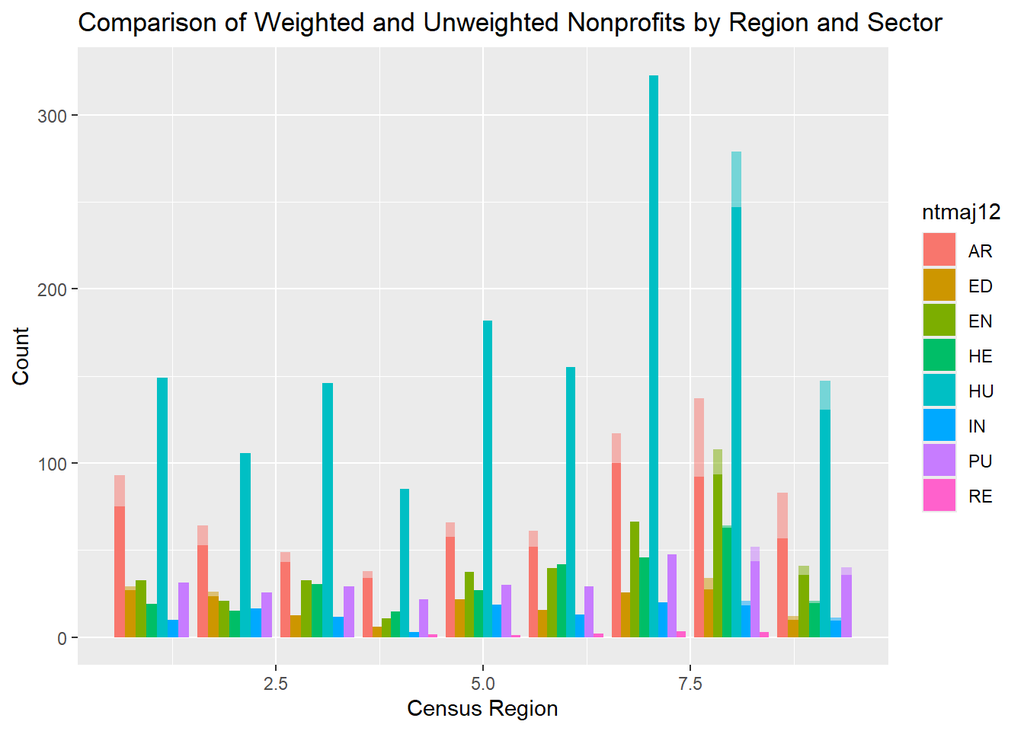

```r
nonprofit_with_region <- data04 |>
  group_by(CensusRegion9, ntmaj12) |>
  summarise(weighted_count = sum(year4wt, na.rm = TRUE), .groups = "drop") |>
  group_by(CensusRegion9) |>
  mutate(percent = 100 * weighted_count / sum(weighted_count)) |>
  ungroup()


nonprofit_unweighted <- data04 |>
  group_by(CensusRegion9, ntmaj12) |>
  summarise(unweighted_count = n(), .groups = "drop")

# Combine weighted and unweighted counts into one dataframe
nonprofit_comparison <- nonprofit_with_region |>
  left_join(nonprofit_unweighted, by = c("CensusRegion9", "ntmaj12"))

# Plot comparison of weighted and unweighted counts by region and sector
ggplot(nonprofit_comparison, aes(x = CensusRegion9, y = weighted_count, fill = ntmaj12)) +
  geom_bar(stat = "identity", position = "dodge") +
  geom_bar(aes(y = unweighted_count), stat = "identity", position = "dodge", alpha = 0.5) +
  labs(title = "Comparison of Weighted and Unweighted Nonprofits by Region and Sector",
       y = "Count",
       x = "Census Region")
```

```r
# Run ANOVA to see if there’s a significant difference between weighted counts by region and sector
anova_weighted_vs_unweighted <- aov(weighted_count ~ CensusRegion9 + ntmaj12, data = nonprofit_comparison)
summary(anova_weighted_vs_unweighted)
```

```
##               Df Sum Sq Mean Sq F value Pr(>F)
## CensusRegion9  1   4370    4370   5.182 0.0265 *
## ntmaj12        7 170052   24293  28.804 <2e-16 ***
## Residuals     59  49759     843
## ---
## Signif. codes:  0 '***' 0.001 '**' 0.01 '*' 0.05 '.' 0.1 ' ' 1
```

```r
# Chi-squared test to compare weighted vs unweighted distributions
chisq_test <- chisq.test(nonprofit_comparison$weighted_count, nonprofit_comparison$unweighted_count)
chisq_test
```

```
##
##  Pearson's Chi-squared test
##
## data:  nonprofit_comparison$weighted_count and nonprofit_comparison$unweighted_count
## X-squared = 3196, df = 3149, p-value = 0.275
```